# Stage 2: Exploratory Data Analysis

Isaac Slagel and Jack Welsh

4/18/2019

# EDA Main Report

## Dogs

Dogs are the most common animal winding up in the animal shelters which form our dataset. From our total of 44,194 dogs, 35% were adopted, 30% were returned to owners, 16% were trasfered, and 15% were euthanized. The most common breed of dog in our dataset is the pitbull, with 10,033 being admited to animal shelters in between 10/01/2017 and 04/03/2019. We are especially interested in how pitbulls are treated within our datasets as these dogs have an infamous reputation of being overly agressive. Is it possible that this reputation results in a lower adoption rate for pitbulls that other breeds?

#### Pitbulls

We see that pitbulls, while only adopted at a slightly lower rate (~5%), are euthanized at well over double the rate of other dogs. Further, we see that other dogs have a much higher chance of being trasfered to another facility or returned to their owner. It would be valuble to get a better understanding of this relationship, but we likely need to control for things like chip status and intake condition. Moving foward we would like to look into some binomial regression to look into the outcomes of pitbulls. To do this we plan to make a more general outcome variable of Dead or Alive status (to reduce the dimension of the current outcome_type variable). In fitting this model we plan to control for intake status (with which we still need to do some work on string analysis), chip_status, and month.

## Dogs vs Cats

In Minnesota and Iowa, our home states, animal shelters often report having more difficulty dealing with stray cats. There are lots of problems that feral cats cause including environmental damage and spread of disease. We were interested if we can see these kinds of differences in our data. Do cats spend longer in animal shelters? Are they euthanized at higher rates? To describe some of these differences we looked we created a summary graph of different characteristics of dogs and cats. Since our dataset contains observations of 44194 dogs and only 12891 cats, we created this chart in terms of proportion of each animal matching a certain critera.

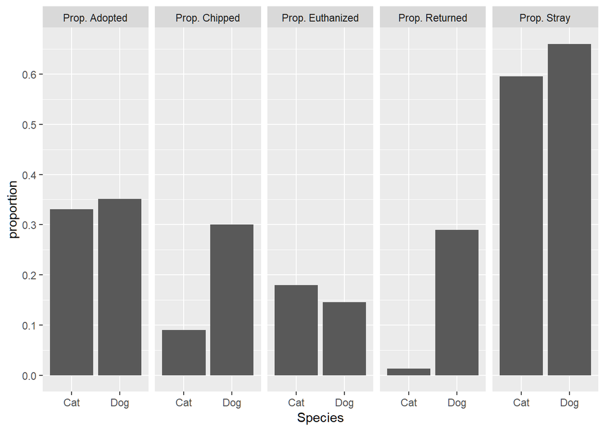

Cat vs Dog Characteristics

Interestingly enough, we see that the difference between proportions of cats and dogs adopted is not very pronounced. A slightly lower percentage of cats are adopted and a slightly higher percent of cats are euthanized compared to dogs. However, we do see that very few cats entering humane societys have scannable chips, and an even lower proportion are returned to their owner. Additionally it seems appears that fewer cats are brought into the shelter as strays. We may use this data to do another binomial analysis to piece apart differences between cat and dog adoptions. We may do a similar thing as the pitbull analysis with the creation of a dead or alive outcome variable. We would want to consider controlling for in this analysis would be breed, intake condition,and chip status.

## Time of Year

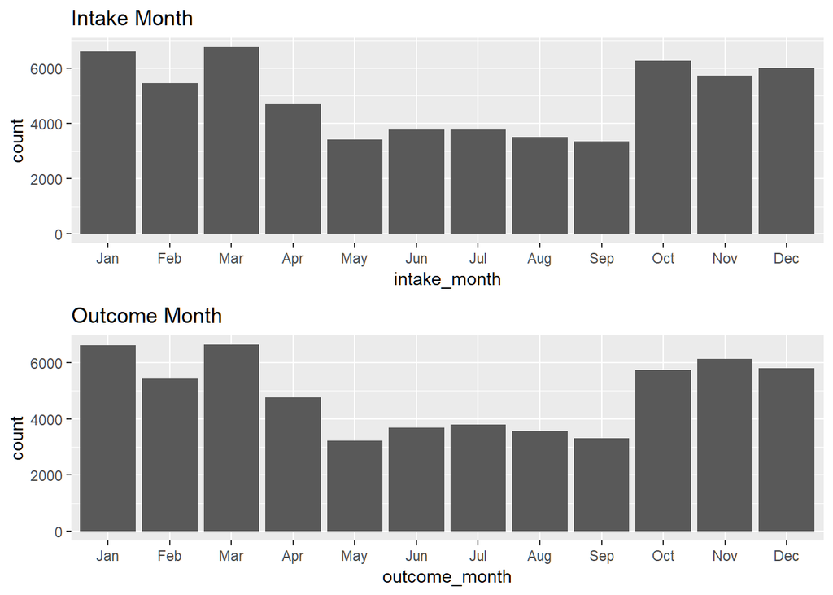

# Annotated Appendix and References

## Citations

1. [Lepper, M., Kass, P. H., & Hart, L. A. (2002). Prediction of adoption versus euthanasia among dogs and cats in a California animal shelter. Journal of Applied Animal Welfare Science, 5(1), 29-42.](https://www.tandfonline.com/doi/abs/10.1207/S15327604JAWS0501_3)
2. [Posage, J. M., Bartlett, P. C., & Thomas, D. K. (1998). Determining factors for successful adoption of dogs from an animal shelter. Journal of the American Veterinary Medical Association, 213(4), 478-482.](https://europepmc.org/abstract/med/9713528)
3. [Lampe, R., & Witte, T. H. (2015). Speed of dog adoption: Impact of online photo traits. Journal of applied animal welfare science, 18(4), 343-354.](https://www.tandfonline.com/doi/abs/10.1080/10888705.2014.982796)

## Exploring animal_type

```r
# animal type
adoptions %>%
  group_by(animal_type) %>%
  count(sort = TRUE)
```

| animal_type | n |
| --- | --- |
| DOG | 44194 |
| CAT | 12891 |
| WILDLIFE | 1696 |
| BIRD | 485 |
| LIVESTOCK | 33 |
| D | 1 |

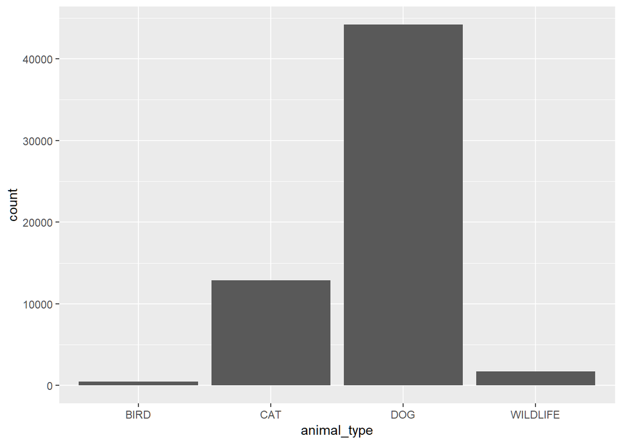

```r
adoptions %>%
  filter(!animal_type%in%c("D", "LIVESTOCK")) %>%
  ggplot(aes(x=animal_type))+
  geom_bar()
```

We see that most observations in our dataaset were of dogs, followed by cats. It seems there is 1 mislabeled dog which we will take care of in our data cleaning file.

## Exploring animal_breed

```r
## Which dog breeds are in our data?
adoptions %>%
  filter(animal_type == "DOG") %>%
  mutate(animal_breed = fct_lump(animal_breed, n=15)) %>%
  group_by(animal_breed) %>%
  count(sort = TRUE)
```

| animal_breed | n |
| --- | --- |
| PIT BULL | 10033 |
| Other | 9423 |
| CHIHUAHUA SH | 6322 |
| GERM SHEPHERD | 5625 |
| LABRADOR RETR | 5353 |
| CAIRN TERRIER | 1430 |
| ALASKAN HUSKY | 812 |
| ROTTWEILER | 751 |
| SHIH TZU | 696 |
| AUST CATTLE DOG | 683 |

[output cut: 6 more lines]

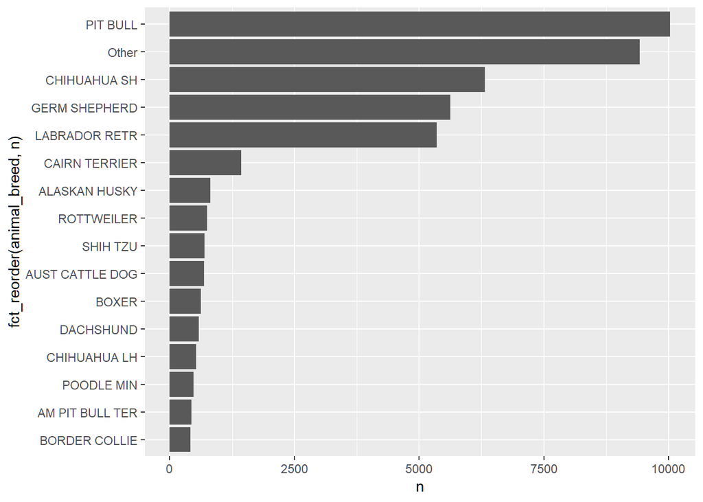

```r
adoptions %>%
  filter(animal_type == "DOG") %>%
  mutate(animal_breed = fct_lump(animal_breed, n=15)) %>%
  group_by(animal_breed) %>%
  count(sort = TRUE)%>%
  ggplot(aes(x=fct_reorder(animal_breed,n), y=n))+
  geom_bar(stat="identity")+
  coord_flip()
```

We have a huge variety of dog breeds in our data. The pmost common breed is the pitbull, which we are planning to use for our analysis. There are many other dog breeds that are seen as agressive (rottweilers and boxers) that we may make into a new variable `aggressive`.

```r
## Which cat breeds are in our data?
adoptions %>%
  filter(animal_type == "CAT") %>%
  mutate(animal_breed = fct_lump(animal_breed, n=10)) %>%
  group_by(animal_breed) %>%
  count(sort = TRUE)
```

| animal_breed | n |
| --- | --- |
| DOMESTIC SH | 11273 |
| DOMESTIC MH | 916 |
| DOMESTIC LH | 219 |
| SIAMESE | 214 |
| AMER SH | 101 |
| RUSSIAN BLUE | 96 |
| Other | 33 |
| MAINE COON | 19 |
| PERSIAN | 8 |
| AMER CURL SH | 6 |

[output cut: 1 more lines]

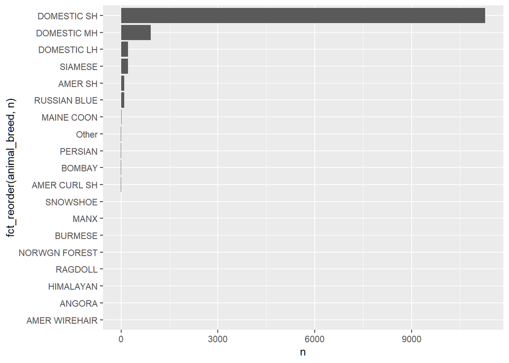

```r
adoptions %>%
  filter(animal_type == "CAT") %>%
  mutate(animal_breed = fct_lump(animal_breed, n=15)) %>%
  group_by(animal_breed) %>%
  count(sort = TRUE)%>%
  ggplot(aes(x=fct_reorder(animal_breed,n), y=n))+
  geom_bar(stat="identity")+
  coord_flip()
```

Almost all of the cats in our data were domestic short hair cats.

```r
## Which types of wildlife are in our data?
adoptions %>%
  filter(animal_type == "WILDLIFE") %>%
  mutate(animal_breed = fct_lump(animal_breed, n=10)) %>%
  group_by(animal_breed) %>%
  count(sort = TRUE)
```

| animal_breed | n |
| --- | --- |
| RACCOON | 471 |
| OPOSSUM | 404 |
| TURTLE | 190 |
| GUINEA PIG | 148 |
| RABBIT SH | 136 |
| HAMSTER | 98 |
| SQUIRREL | 82 |
| Other | 68 |
| BAT | 59 |
| FOX | 23 |

[output cut: 1 more lines]

This variable is more for fun. Look at all these fun creatures they get to deal with at the animal shelter. We are kind of interested in rabbits so we will talk about that later.

## Exploring animal origin

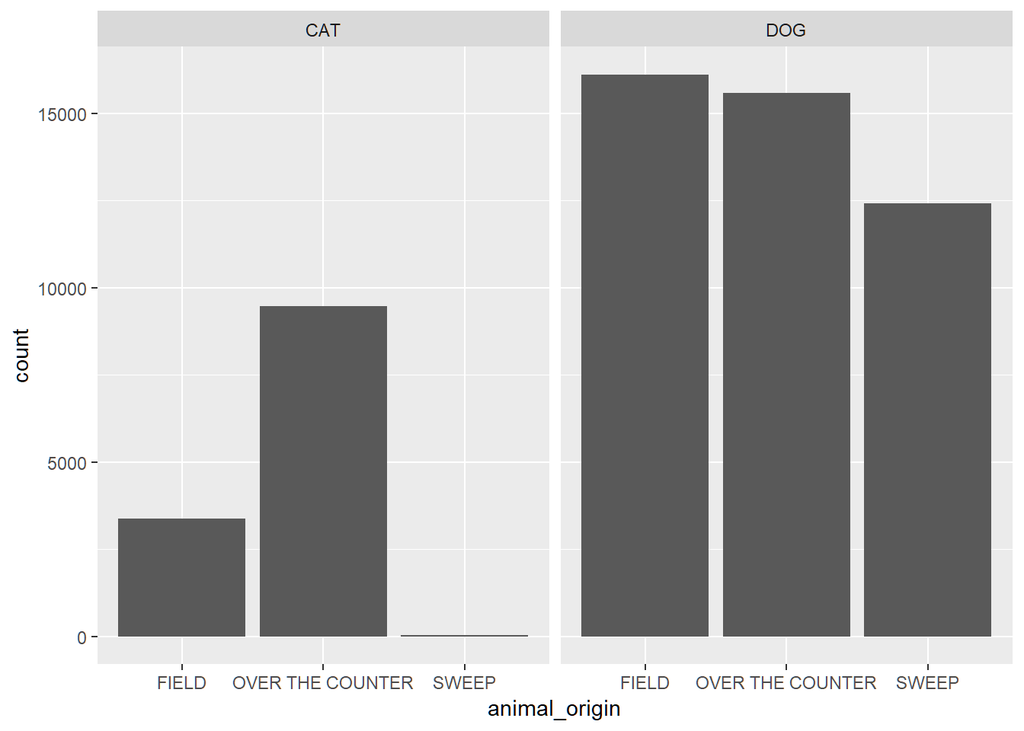

```r
adoptions %>%
  filter(dog == 1 | cat == 1) %>%
  filter(!is.na(animal_origin)) %>%
  ggplot(aes(x=animal_origin))+
  geom_bar()+
  facet_grid(~animal_type)
```

Dogs and cats can come from a 3 possible origins: field, over the counter, and sweep. As of this moment, we are not sure what the difference between field and sweep are. However, it is interesting that only dogs are brought in from sweeps.

## Exploring chip status

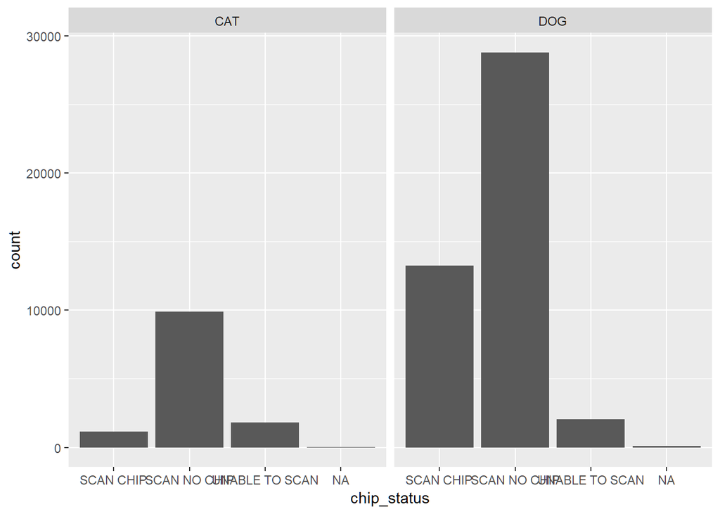

```r
## General distribution of variable
adoptions %>%
  filter(dog == 1 | cat == 1) %>%
  ggplot(aes(x=chip_status))+
  geom_bar()+
  facet_grid(~animal_type)
```

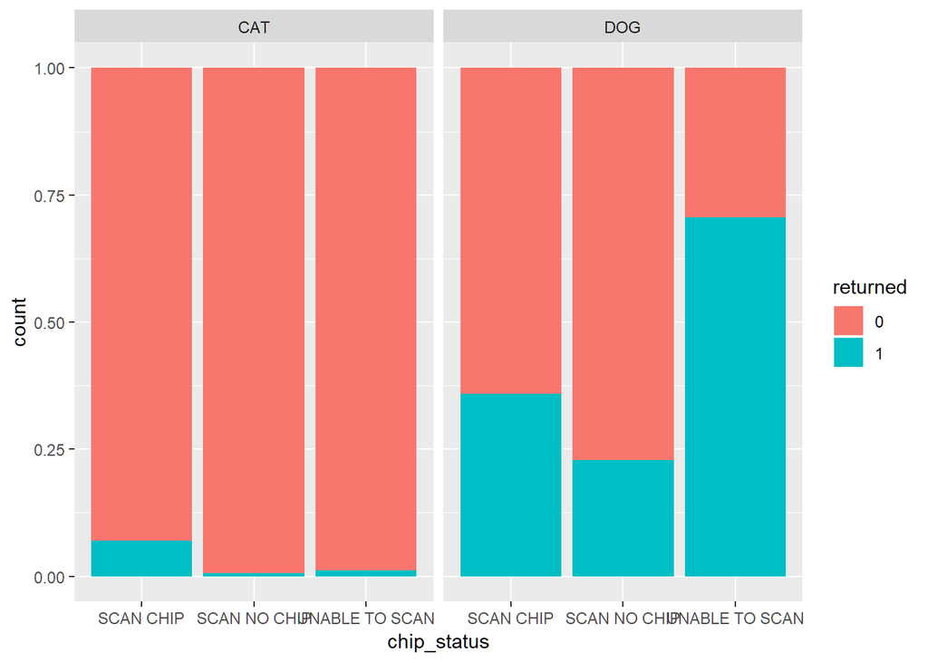

```r
## Relationship with returned to owner status
adoptions %>%
  filter(dog == 1 | cat == 1) %>%
  filter(!is.na(chip_status)) %>%
  mutate(returned = as.factor(ifelse(outcome_type== "RETURNED TO OWNER", 1, 0))) %>%
  ggplot(aes(x=chip_status, fill = returned))+
  geom_bar(position = "fill")+
  facet_grid(~animal_type)
```

We see that most cats and dogs do not have chips. However, a larger proportion of dogs have chips than cats.

A higher proportion of dogs are returned to owners than cats in all three categories of chip status.

## Exploring intake_subtype

```r
## Which dog breeds are in our data?
adoptions %>%
  mutate(intake_subtype = fct_lump(intake_subtype, n=10)) %>%
  group_by(intake_subtype) %>%
  count(sort = TRUE)
```

| intake_subtype | n |
| --- | --- |
| AT LARGE | 28889 |
| GENERAL | 15495 |
| CONFINED | 5598 |
| POSSIBLY OWNED | 2085 |
| Other | 1813 |
| QUARANTINE | 1454 |
| RETURN30 | 1312 |
| INJURED | 972 |
| KEEP SAFE | 781 |
| UNINJURED | 474 |

[output cut: 1 more lines]

This general intake listing does not give us a lot of infomration. However we do see that a few animals may have been returned (non-independent observation), and some animals are requested to be euthanized upon admission.

## Exploring intake_date and outcome_date

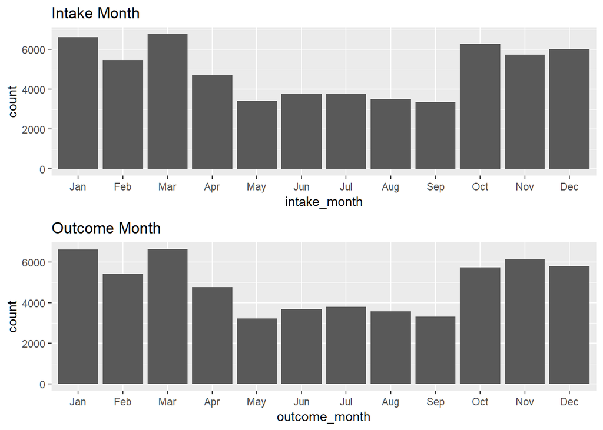

```r
intake <- adoptions %>%
  mutate(intake_month = month(intake_date, label = TRUE)) %>%
  ggplot(aes(x=intake_month))+
  geom_bar()+
  ggtitle("Intake Month")

outcome <- adoptions %>%
  filter(!is.na(outcome_date)) %>%
  mutate(outcome_month = month(outcome_date, label = TRUE)) %>%
  ggplot(aes(x=outcome_month))+
  geom_bar()+ ggtitle("Outcome Month")
gridExtra::grid.arrange(intake, outcome)
```

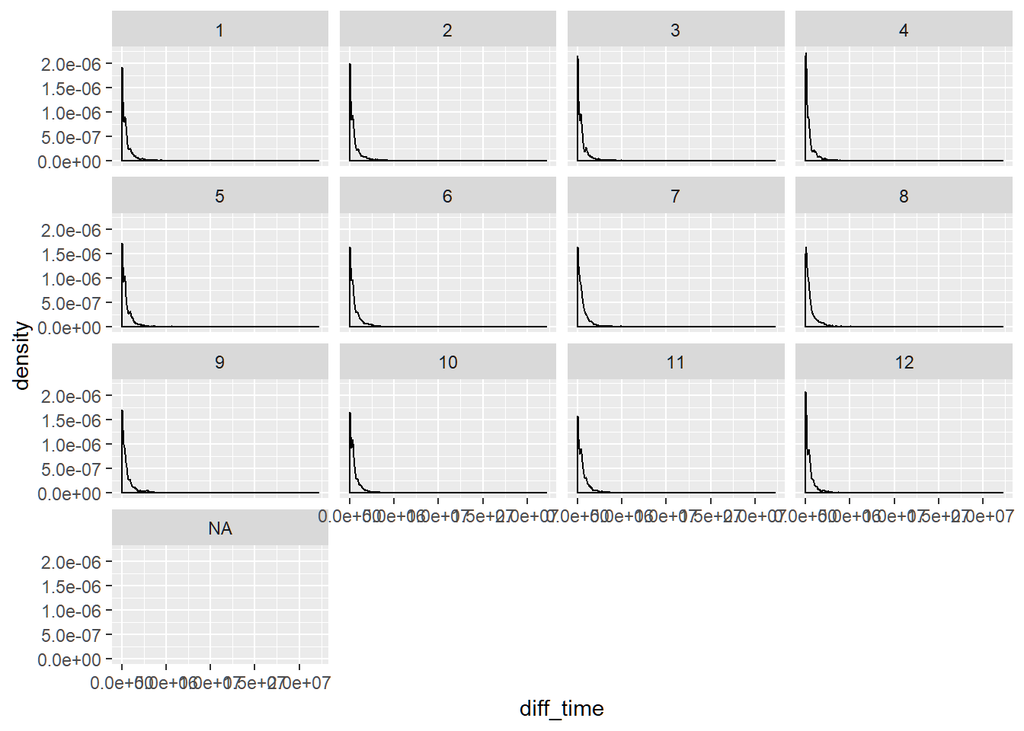

```r
# Ammount of time spent at the humane society looks to be about the same from month to month.

adoptions %>%
  mutate(diff_time=difftime(outcome_date, intake_date))%>%
  select(diff_time, month)%>%
  ggplot(aes(x=diff_time))+
  geom_density()+
  facet_wrap(~as.factor(month))
```

### Differences in income day

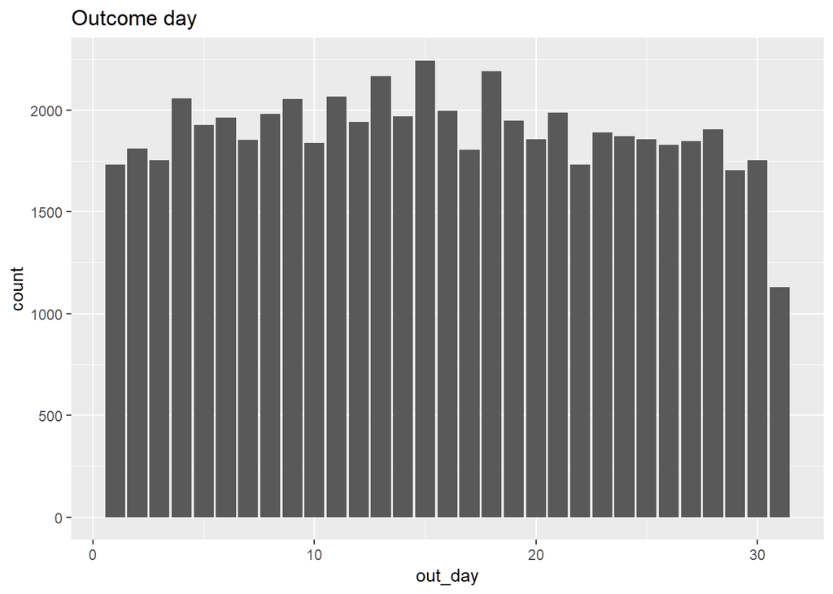

```r
adoptions%>%
  mutate(out_day=day(outcome_date))%>%
  ggplot(aes(x=out_day))+
  geom_bar()+ ggtitle("Outcome day")
```

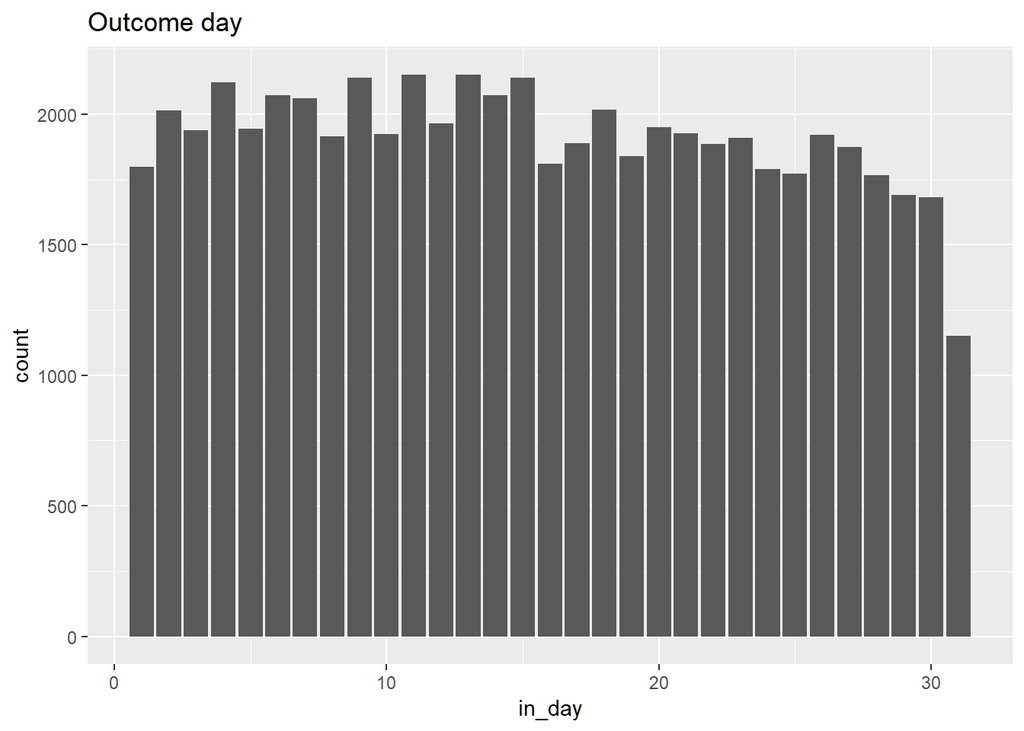

```r
adoptions%>%
  mutate(in_day=day(intake_date))%>%
  ggplot(aes(x=in_day))+
  geom_bar()+ ggtitle("Outcome day")
```

## Pitbulls and Adoptions

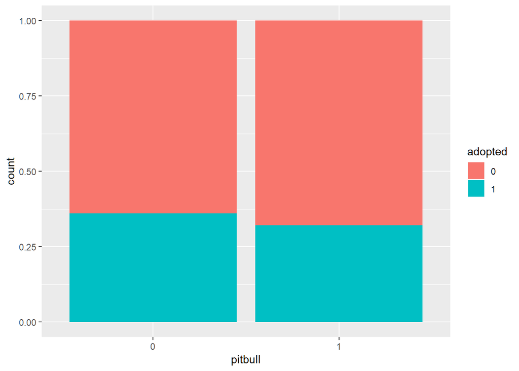

```r
adoptions %>%
  filter(dog == 1) %>%
  mutate(adopted = as.factor(adopted),
         pitbull = as.factor(pitbull)) %>%
  ggplot(aes(x = pitbull, fill = adopted))+
  geom_bar(position = "fill")
```

There does not seem to be a large difference between the adoption rates of pitbull and non-pitbulls. We should try and filter out some of the non-adopted dogs though, not all dogs come to the shelter to be adopted.

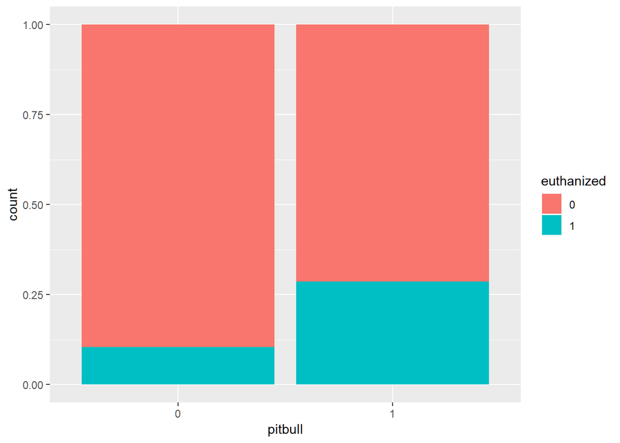

```r
adoptions %>%
  filter(dog == 1) %>%
  mutate(euthanized = as.factor(euthanized),
         pitbull = as.factor(pitbull)) %>%
  ggplot(aes(x = pitbull, fill = euthanized))+
  geom_bar(position = "fill")
```

While pitbulls are not adopted at a higher rate, the are euthanized at a higher rate than other dogs. Lets look at all possible outcomes to see how this is possible.

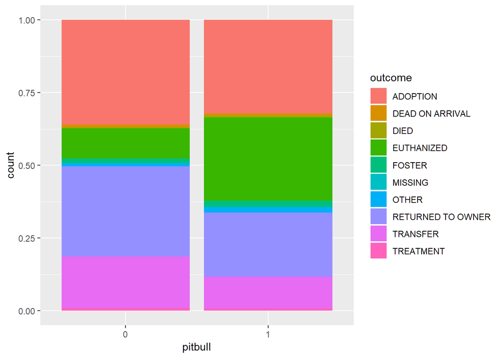

```r
adoptions %>%
  filter(dog == 1) %>%
  mutate(outcome = as.factor(outcome_type),
         pitbull = as.factor(pitbull)) %>%
  ggplot(aes(x = pitbull, fill = outcome))+
  geom_bar(position = "fill")
```

```r
adoptions %>%
  filter(dog == 1) %>%
  mutate(outcome = as.factor(outcome_type),
         pitbull = as.factor(pitbull)) %>%
  group_by(pitbull, outcome_type) %>%
  count() %>%
  rename("freq"=n)%>%
  group_by(pitbull)%>%
  mutate(freq = freq/ sum(freq))%>%
  spread(outcome_type,freq)
```

| pitbull | ADOPTION | DEAD ON ARRIVAL | DIED | EUTHANIZED | FOSTER | MISSING | OTHER | RETURNED TO OWNER | TRANSFER | TREATMENT |
| --- | --- | --- | --- | --- | --- | --- | --- | --- | --- | --- |
| 0 | 0.3603524 | 0.008313574 | 0.003864056 | 0.104271 | 0.01571968 | 0.0006147361 | 0.009894324 | 0.3100905 | 0.1774245 | 0.009455227 |
| 1 | 0.3210406 | 0.008771056 | 0.005182896 | 0.286654 | 0.02162863 | 0.0003986843 | 0.018339480 | 0.2202731 | 0.1098375 | 0.007874016 |

A far higher percentage of pitbulls are euthanized than other breeds. Other dogs are adopted, returned to owners, and trasfered at a higher rate.

## Differences between dogs and cats

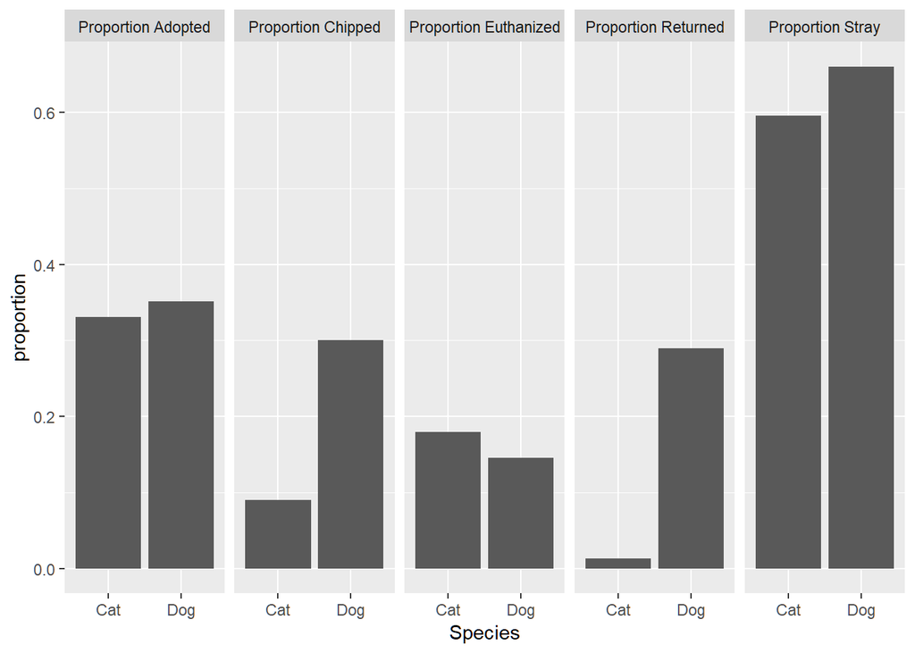

```r
adoptions %>%
  filter(dog == 1 | cat == 1) %>%
  mutate(Species = ifelse(dog == 1, "Dog", "Cat")) %>%
  mutate(returned = ifelse(outcome_type == "RETURNED TO OWNER", 1, 0)) %>%
  group_by(Species) %>%
  summarise(count = n(),
            meanDays = mean(shelter_days, na.rm = TRUE),
            `Proportion Euthanized` = sum(euthanized)/count,
            `Proportion Adopted` = sum(adopted)/count,
            `Proportion Stray` = sum(stray)/count,
           `Proportion Returned` = sum(returned)/count,
           `Proportion Chipped` = sum(chip_status == "SCAN CHIP", na.rm = TRUE)/count)%>%
  gather(key = key, value = proportion, 4:8) %>%
  ggplot(aes(x=Species, y= proportion)) +
    geom_bar(stat = "identity")+
    facet_grid(cols = vars(key))
```

Cats are returned at a much lower rate than dogs. Cats have a much lower proportion with scannable chips than dogs.

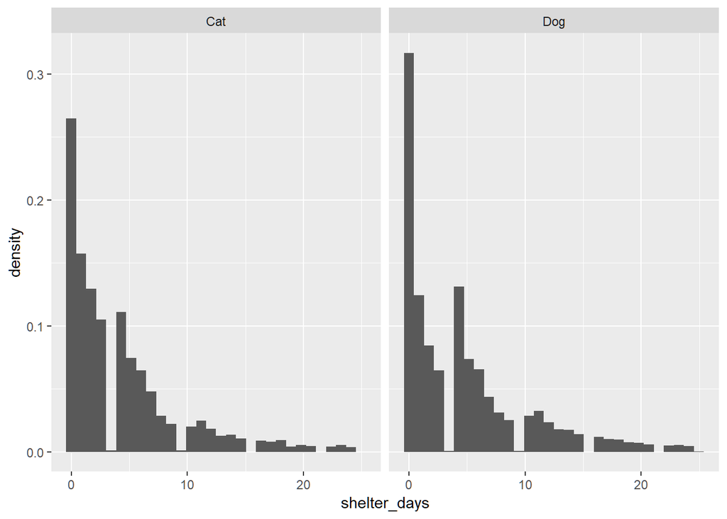

```r
adoptions %>%
  filter(dog == 1 | cat == 1) %>%
  filter(shelter_days < 25) %>%
  mutate(DogCat = ifelse(dog == 1, "Dog", "Cat")) %>%
  ggplot(aes(x=shelter_days, y=..density..)) +
  geom_histogram()+
  facet_grid(~DogCat)
```

Dogs and cats show similar trends in the number of days until adoptions.

## What about rabbits?

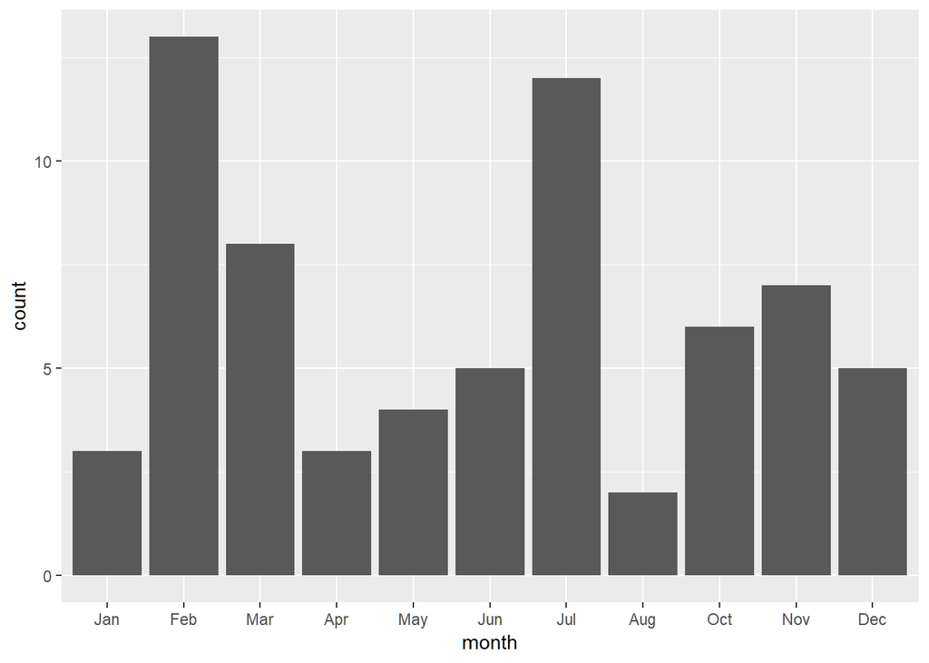

```r
adoptions  %>%
  filter(animal_breed== "RABBIT SH") %>%
  filter(adopted == 1) %>%
  mutate(month = lubridate::month(outcome_date, label = TRUE)) %>%
  ggplot(aes(x=month)) +
  geom_bar()
```

Alright, so maybe it is not the case that more rabits are adopted over easter. Are there trends in dog adoptions?

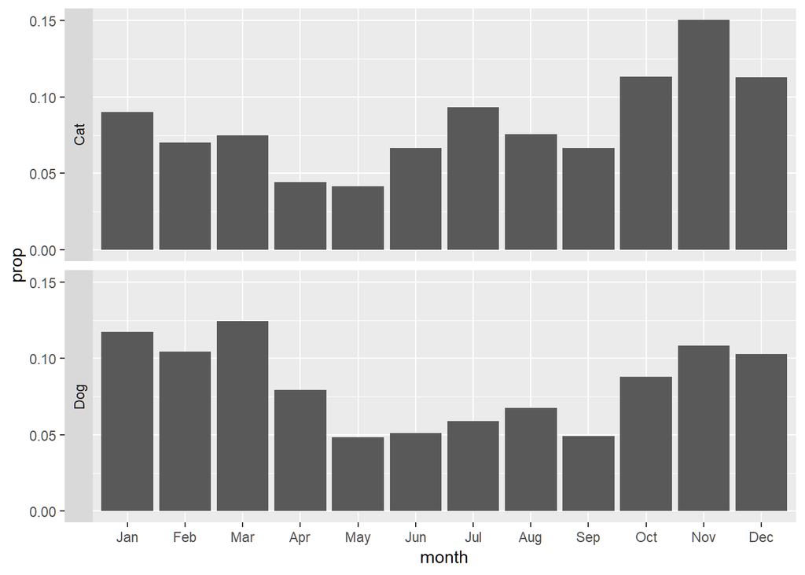

```r
adoptions  %>%
  filter(dog == 1 | cat == 1) %>%
  mutate(DogCat = ifelse(dog == 1, "Dog", "Cat")) %>%
  filter(adopted == 1, !is.na(month)) %>%
  mutate(month = lubridate::month(outcome_date, label = TRUE)) %>%
  ggplot(aes(x=month, y = ..prop.., group = 1)) +
  geom_bar()+
  facet_grid(rows = vars(DogCat), switch = "both")
```